# Attrition and Salary Analysis - Case Study 2

Roslyn Smith

4/16/2022

Importing packages

Importing datasets

Adjustments to data provided

I excluded employee unique identifiers as well as columns with same data from the analysis to better group employees and reduce dataset. In addition, I converted the Attrition Yes / No indicators to binary 0/1 in order to better run a model.

Columns Excluded: Employee Unique Identifiers - ID and Employee Number Columns with no differentiation in data - Employee Count: Value is all 1 - Over 18: Value is all Yes - Standard Hours: Value is all 80 hours

Initial Attrition Model

Create an initial model to determine significant variables that impact attrition

```
##
## Call:
## lm(formula = attrition2 ~ . - attrition, data = model_data)
##
## Residuals:
##      Min       1Q   Median       3Q      Max
## -0.56112 -0.20251 -0.07929  0.09053  1.11279
##
## Coefficients:
##                                    Estimate Std. Error t value Pr(>|t|)
## (Intercept)                       6.672e-01  2.315e-01   2.882 0.004054 **
## age                              -2.864e-03  1.702e-03  -1.683 0.092770 .
## businesstravelTravel_Frequently   9.251e-02  4.277e-02   2.163 0.030822 *
## businesstravelTravel_Rarely       3.806e-02  3.639e-02   1.046 0.295874
## dailyrate                        -1.720e-05  2.756e-05  -0.624 0.532808
## departmentResearch & Development  1.462e-01  1.437e-01   1.017 0.309461
## departmentSales                   1.666e-01  1.471e-01   1.132 0.257782
## distancefromhome                  4.093e-03  1.373e-03   2.981 0.002953 **
## education                        -5.942e-03  1.120e-02  -0.530 0.595965
## educationfieldLife Sciences      -2.137e-01  1.110e-01  -1.924 0.054677 .
## educationfieldMarketing          -2.012e-01  1.177e-01  -1.709 0.087850 .
## educationfieldMedical            -2.187e-01  1.113e-01  -1.965 0.049770 *
## educationfieldOther              -2.057e-01  1.188e-01  -1.731 0.083786 .
## educationfieldTechnical Degree   -1.388e-01  1.158e-01  -1.198 0.231118
## environmentsatisfaction          -2.794e-02  1.010e-02  -2.766 0.005802 **
## genderMale                        2.117e-02  2.247e-02   0.942 0.346329
## hourlyrate                        5.961e-04  5.500e-04   1.084 0.278778
## jobinvolvement                   -8.188e-02  1.579e-02  -5.184 2.73e-07 ***
## joblevel                         -1.698e-02  3.855e-02  -0.441 0.659663
## jobroleHuman Resources            1.707e-01  1.552e-01   1.100 0.271800
## jobroleLaboratory Technician      6.568e-02  5.198e-02   1.264 0.206721
## jobroleManager                   -7.536e-03  9.646e-02  -0.078 0.937751
## jobroleManufacturing Director    -6.663e-02  5.109e-02  -1.304 0.192519
## jobroleResearch Director         -6.602e-02  7.854e-02  -0.841 0.400833
## jobroleResearch Scientist         1.507e-02  5.145e-02   0.293 0.769691
## jobroleSales Executive            1.362e-02  1.079e-01   0.126 0.899590
## jobroleSales Representative       2.230e-01  1.179e-01   1.891 0.058955 .
## jobsatisfaction                  -4.329e-02  9.949e-03  -4.352 1.52e-05 ***
## maritalstatusMarried              5.192e-02  3.010e-02   1.725 0.084876 .
## maritalstatusSingle               1.358e-01  4.053e-02   3.351 0.000842 ***
## monthlyincome                     7.480e-06  1.048e-05   0.714 0.475733
## monthlyrate                      -9.249e-07  1.553e-06  -0.595 0.551704
## numcompaniesworked                2.064e-02  5.048e-03   4.088 4.78e-05 ***
## overtimeYes                       2.108e-01  2.436e-02   8.655  < 2e-16 ***
## percentsalaryhike                 1.633e-03  4.776e-03   0.342 0.732447
## performancerating                 1.628e-02  4.881e-02   0.334 0.738819
## relationshipsatisfaction         -2.388e-02  1.000e-02  -2.388 0.017147 *
## stockoptionlevel                 -1.192e-02  1.715e-02  -0.695 0.487270
## totalworkingyears                -6.693e-03  3.346e-03  -2.001 0.045772 *
## trainingtimeslastyear            -1.876e-02  8.765e-03  -2.140 0.032642 *
## worklifebalance                  -4.253e-02  1.550e-02  -2.743 0.006212 **
## yearsatcompany                    5.119e-03  4.103e-03   1.248 0.212549
## yearsincurrentrole               -8.667e-03  5.122e-03  -1.692 0.090986 .
## yearssincelastpromotion           1.517e-02  4.600e-03   3.297 0.001020 **
## yearswithcurrmanager             -7.063e-03  5.032e-03  -1.404 0.160823
## ---
## Signif. codes:  0 '***' 0.001 '**' 0.01 '*' 0.05 '.' 0.1 ' ' 1
##
## Residual standard error: 0.3184 on 825 degrees of freedom
## Multiple R-squared:  0.288,  Adjusted R-squared:   0.25
## F-statistic: 7.585 on 44 and 825 DF,  p-value: < 2.2e-16
```

In running a linear regression model with all variables, the variables with the most significance were: - Overtime completed - Job Involvement - Job Satisfaction - Number of Companies Worked - Marital Status

Plotting Attrition vs. Key Variables

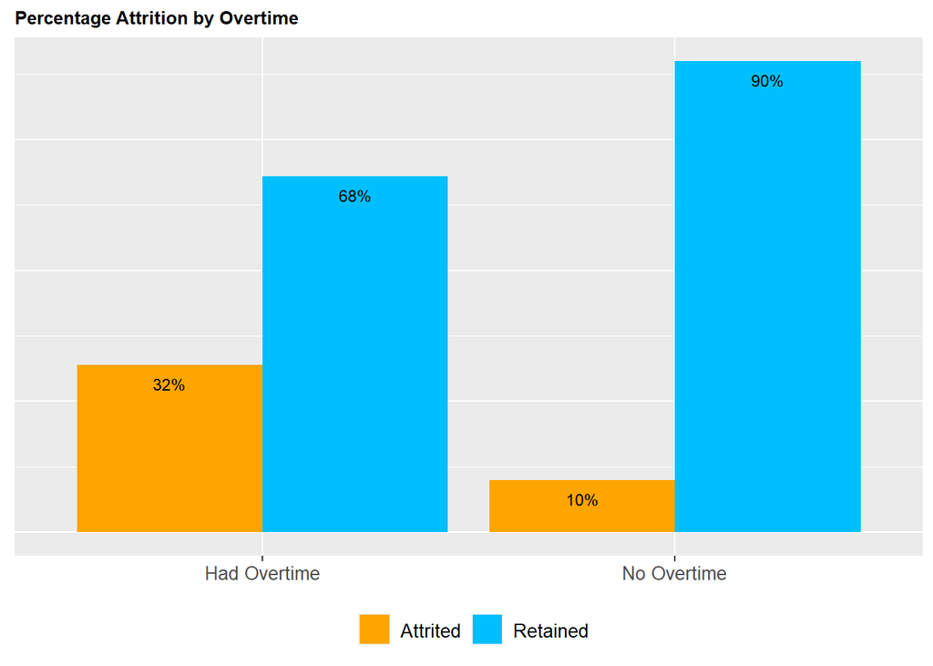

The column chart shows a higher percentage of employees who worked overtime also attrited.

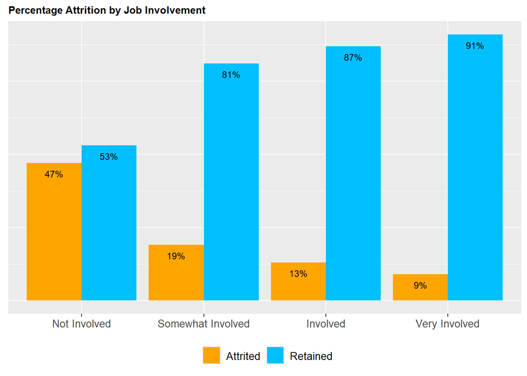

As job involvement increases, we see a decrease in attrition.

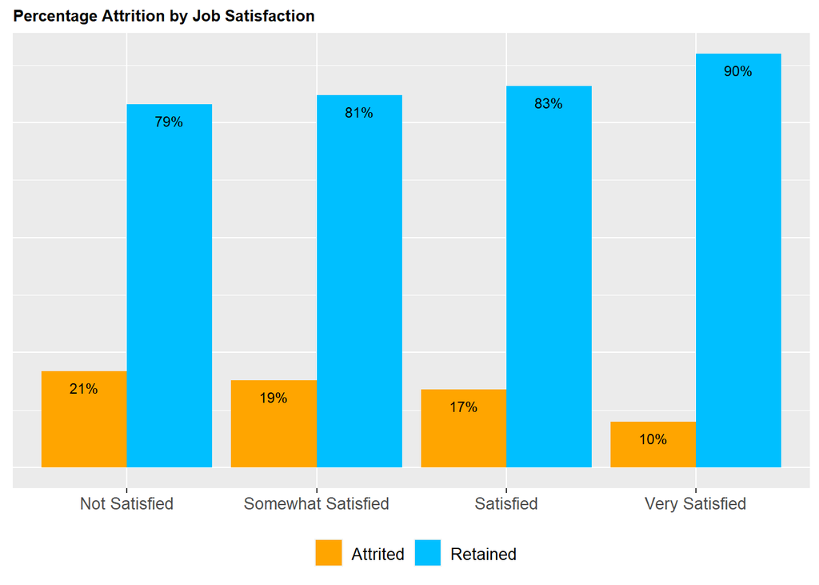

Similar to job involvement, we see an inverse trend with job satisfaction and attrition.

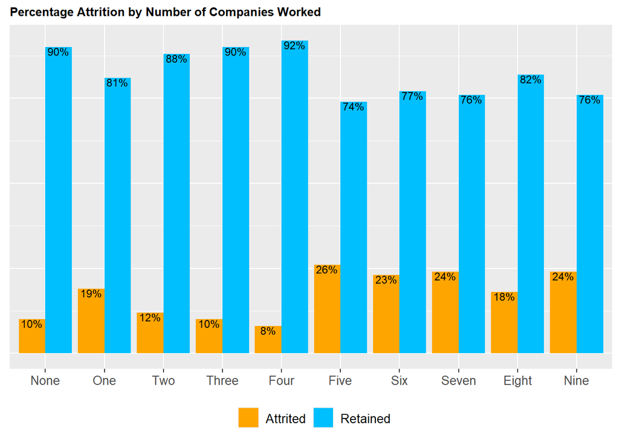

As there is an increase in the number of companies the employees worked with, we see an increasing trend of attrition.

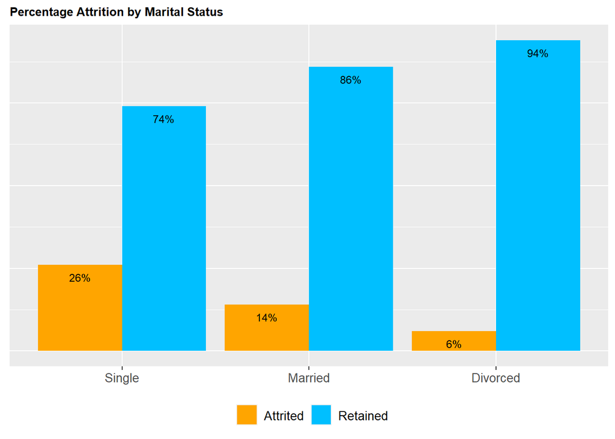

Employees’ personal life also impact attrition. There is a higher proportion of single employees that attrited when compared to married or divorced employees.

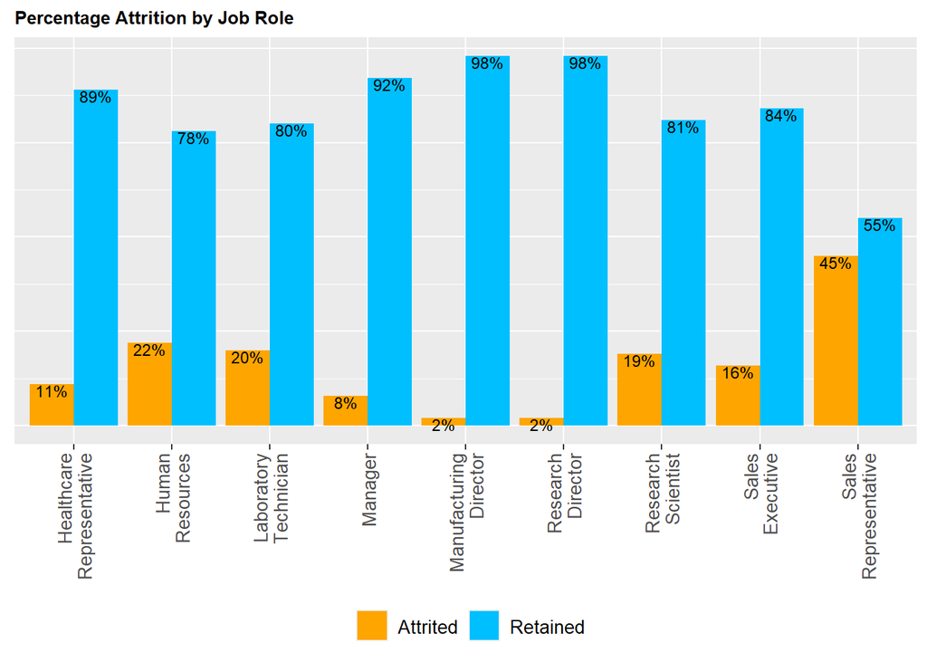

There is significantly higher attrition in the Sales Representative role which is not replicated in any other role.

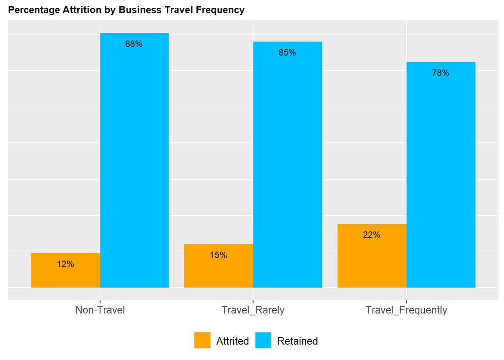

There is also an increasing trend of attrition as the volume of business travel also increases.

Classifying Attrition

Naïve Bayes model was used in order to classify attrition. 75% of the employee data was split into a training set and the remaining was used as a test set in order to test the accuracy of the model. The metrics used for the model were:Age, Business Travel, Department, Distance from Home, Education Level, Environment Satisfaction, Hourly Rate, Job Involvement, Job Level, Job Role, Job Satisfaction, Marital Status, Monthly Income, Overtime, Performance Rating, Relationship Satisfaction, Total Working Years, Work Life Balance, Years At Company, Years In Current Role, Years Since Last Promotion, Years With Current Manager

```
## Confusion Matrix and Statistics
##
##
##        No Yes
##   No  167  15
##   Yes  12  24
##
##                Accuracy : 0.8761
##                  95% CI : (0.8249, 0.9168)
##     No Information Rate : 0.8211
##     P-Value [Acc > NIR] : 0.01776
##
##                   Kappa : 0.5654
##
##  Mcnemar's Test P-Value : 0.70031
##
##             Sensitivity : 0.9330
##             Specificity : 0.6154
##          Pos Pred Value : 0.9176
##          Neg Pred Value : 0.6667
##              Prevalence : 0.8211
##          Detection Rate : 0.7661
##    Detection Prevalence : 0.8349
##       Balanced Accuracy : 0.7742
##
##        'Positive' Class : No
##
```

Additional Insights

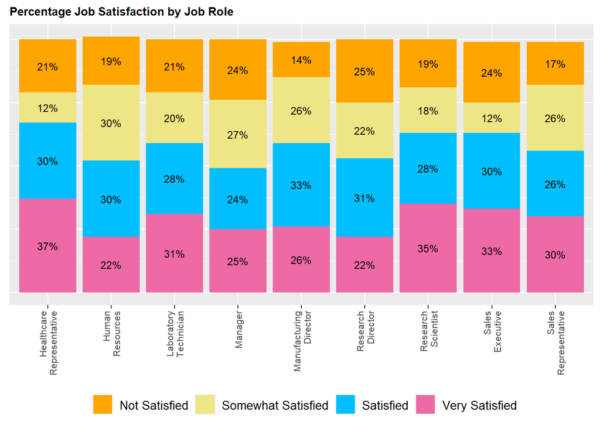

Generally all roles are more than 50% Satisfied or Very Satisfied (3 or 4 in response). Manager roles were at 49% in those two categories.

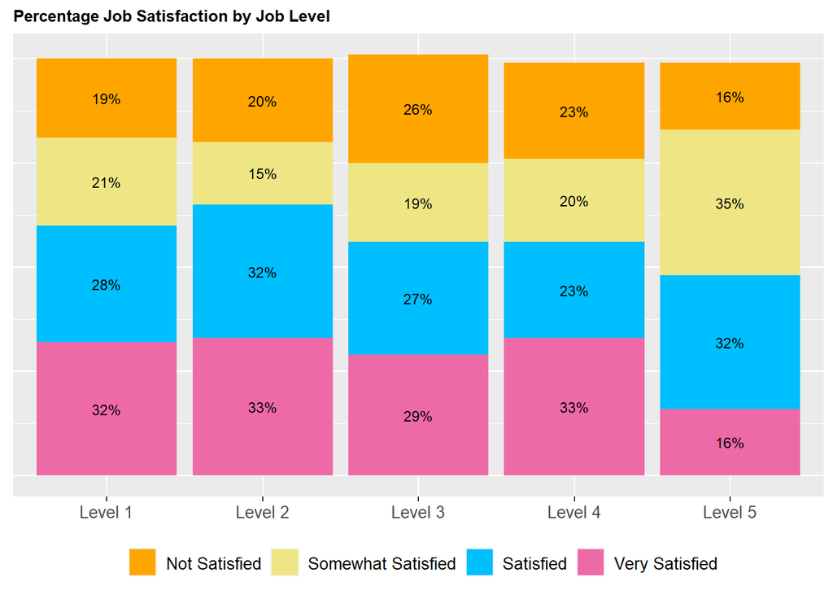

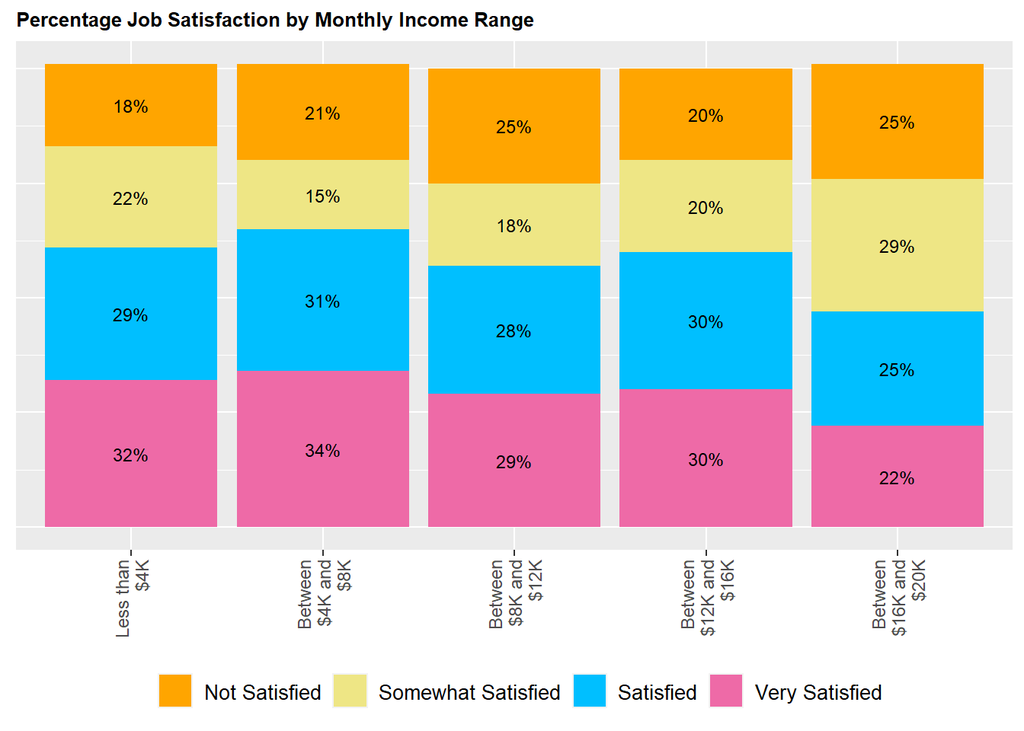

Similar to job levels, the higher paid employees then to be less satisfied.

Predicting Salary

In using these variables, we were able to get a Root Mean Square Error (RMSE) of 1,122. The RMSE measures how concentrated the data is around the line of best fit.

```
##
## Call:
## lm(formula = monthlyincome ~ ., data = train_salary_lm)
##
## Residuals:
##     Min      1Q  Median      3Q     Max
## -3497.2  -630.0   -21.3   625.0  4119.3
##
## Coefficients: (1 not defined because of singularities)
##                                    Estimate Std. Error t value Pr(>|t|)
## (Intercept)                      -4.016e+02  8.646e+02  -0.464  0.64249
## age                               7.072e-01  6.346e+00   0.111  0.91131
## attritionYes                      1.196e+02  1.353e+02   0.884  0.37725
## businesstravelTravel_Frequently   1.540e+02  1.614e+02   0.955  0.34019
## businesstravelTravel_Rarely       4.197e+02  1.337e+02   3.139  0.00178 **
## dailyrate                         2.520e-01  1.050e-01   2.400  0.01667 *
## departmentResearch & Development  2.833e+02  5.019e+02   0.565  0.57260
## departmentSales                  -3.714e+02  5.105e+02  -0.727  0.46721
## distancefromhome                 -1.548e+00  5.154e+00  -0.300  0.76403
## education                        -1.407e+01  4.187e+01  -0.336  0.73690
## educationfieldLife Sciences      -3.586e+01  4.172e+02  -0.086  0.93154
## educationfieldMarketing           3.735e+01  4.422e+02   0.084  0.93272
## educationfieldMedical            -1.338e+02  4.183e+02  -0.320  0.74916
## educationfieldOther              -2.717e+01  4.509e+02  -0.060  0.95197
## educationfieldTechnical Degree   -6.355e+01  4.351e+02  -0.146  0.88394
## environmentsatisfaction          -1.097e+01  3.905e+01  -0.281  0.77893
## genderMale                        1.265e+02  8.496e+01   1.489  0.13694
## hourlyrate                       -3.091e-01  2.123e+00  -0.146  0.88428
## jobinvolvement                    4.616e+01  5.968e+01   0.774  0.43950
## joblevel                          2.843e+03  9.576e+01  29.689  < 2e-16 ***
## jobroleHuman Resources            6.329e+01  5.508e+02   0.115  0.90857
## jobroleLaboratory Technician     -5.740e+02  1.924e+02  -2.983  0.00297 **
## jobroleManager                    4.490e+03  3.303e+02  13.590  < 2e-16 ***
## jobroleManufacturing Director     3.161e+02  1.933e+02   1.635  0.10255
## jobroleResearch Director          4.154e+03  2.543e+02  16.336  < 2e-16 ***
## jobroleResearch Scientist        -2.503e+02  1.932e+02  -1.296  0.19554
## jobroleSales Executive            5.093e+02  4.053e+02   1.257  0.20937
## jobroleSales Representative       2.677e+02  4.445e+02   0.602  0.54731
## jobsatisfaction                   4.606e+01  3.836e+01   1.201  0.23029
## maritalstatusMarried              1.233e+01  1.137e+02   0.108  0.91365
## maritalstatusSingle              -7.891e+01  1.553e+02  -0.508  0.61153
## monthlyrate                      -8.370e-03  6.021e-03  -1.390  0.16498
## numcompaniesworked               -1.900e+00  1.945e+01  -0.098  0.92220
## overtimeYes                      -5.180e+01  9.705e+01  -0.534  0.59370
## percentsalaryhike                 3.444e+01  1.805e+01   1.908  0.05690 .
## performancerating                -3.233e+02  1.827e+02  -1.769  0.07742 .
## relationshipsatisfaction         -6.705e+00  3.740e+01  -0.179  0.85779
## stockoptionlevel                 -8.508e+01  6.603e+01  -1.288  0.19807
## totalworkingyears                 4.089e+01  1.236e+01   3.307  0.00100 **
## trainingtimeslastyear             2.212e+01  3.346e+01   0.661  0.50873
## worklifebalance                  -3.278e+01  6.142e+01  -0.534  0.59370
## yearsatcompany                   -1.347e+01  1.606e+01  -0.838  0.40225
## yearsincurrentrole                2.156e+01  2.047e+01   1.053  0.29270
## yearssincelastpromotion           4.013e+01  1.763e+01   2.277  0.02315 *
## yearswithcurrmanager             -3.243e+01  2.025e+01  -1.602  0.10971
## attrition2                               NA         NA      NA       NA
## ---
## Signif. codes:  0 '***' 0.001 '**' 0.01 '*' 0.05 '.' 0.1 ' ' 1
##
## Residual standard error: 1039 on 607 degrees of freedom
## Multiple R-squared:  0.9539, Adjusted R-squared:  0.9506
## F-statistic: 285.6 on 44 and 607 DF,  p-value: < 2.2e-16
```

```
##
## Call:
## lm(formula = monthlyincome ~ businesstravel + joblevel + jobrole +
##     totalworkingyears + yearssincelastpromotion, data = train_salary_lm)
##
## Residuals:
##     Min      1Q  Median      3Q     Max
## -3632.0  -610.6   -28.5   578.6  4122.6
##
## Coefficients:
##                                 Estimate Std. Error t value Pr(>|t|)
## (Intercept)                     -501.948    248.198  -2.022 0.043555 *
## businesstravelTravel_Frequently  169.184    156.484   1.081 0.280035
## businesstravelTravel_Rarely      428.302    129.584   3.305 0.001002 **
## joblevel                        2851.784     91.932  31.021  < 2e-16 ***
## jobroleHuman Resources          -213.447    279.075  -0.765 0.444650
## jobroleLaboratory Technician    -602.763    188.459  -3.198 0.001450 **
## jobroleManager                  4134.494    258.806  15.975  < 2e-16 ***
## jobroleManufacturing Director    237.713    188.362   1.262 0.207410
## jobroleResearch Director        4113.822    247.706  16.608  < 2e-16 ***
## jobroleResearch Scientist       -267.171    189.338  -1.411 0.158708
## jobroleSales Executive          -141.327    162.005  -0.872 0.383339
## jobroleSales Representative     -303.969    240.181  -1.266 0.206124
## totalworkingyears                 33.069      9.345   3.539 0.000431 ***
## yearssincelastpromotion           22.213     14.429   1.539 0.124178
## ---
## Signif. codes:  0 '***' 0.001 '**' 0.01 '*' 0.05 '.' 0.1 ' ' 1
##
## Residual standard error: 1038 on 638 degrees of freedom
## Multiple R-squared:  0.9516, Adjusted R-squared:  0.9506
## F-statistic: 965.1 on 13 and 638 DF,  p-value: < 2.2e-16
```

```
## [1] 1122.576
```

```
##
## Call:
## lm(formula = monthlyincome ~ businesstravel + joblevel + jobrole +
##     totalworkingyears + yearssincelastpromotion, data = model_data)
##
## Residuals:
##     Min      1Q  Median      3Q     Max
## -3800.5  -627.2   -12.4   594.3  4046.5
##
## Coefficients:
##                                 Estimate Std. Error t value Pr(>|t|)
## (Intercept)                     -393.706    221.763  -1.775 0.076196 .
## businesstravelTravel_Frequently  202.240    138.914   1.456 0.145796
## businesstravelTravel_Rarely      392.749    117.514   3.342 0.000867 ***
## joblevel                        2790.601     81.378  34.292  < 2e-16 ***
## jobroleHuman Resources          -365.896    250.365  -1.461 0.144258
## jobroleLaboratory Technician    -610.884    168.138  -3.633 0.000297 ***
## jobroleManager                  4000.833    228.261  17.527  < 2e-16 ***
## jobroleManufacturing Director    117.235    166.430   0.704 0.481371
## jobroleResearch Director        4010.634    215.069  18.648  < 2e-16 ***
## jobroleResearch Scientist       -339.852    168.393  -2.018 0.043882 *
## jobroleSales Executive           -71.249    143.282  -0.497 0.619130
## jobroleSales Representative     -419.127    211.310  -1.983 0.047634 *
## totalworkingyears                 44.181      8.338   5.298 1.49e-07 ***
## yearssincelastpromotion           16.687     12.754   1.308 0.191084
## ---
## Signif. codes:  0 '***' 0.001 '**' 0.01 '*' 0.05 '.' 0.1 ' ' 1
##
## Residual standard error: 1056 on 856 degrees of freedom
## Multiple R-squared:  0.9481, Adjusted R-squared:  0.9473
## F-statistic:  1202 on 13 and 856 DF,  p-value: < 2.2e-16
```